# 04.3_rf_SDM

Markus Min

2025-11-26

## Description

In this document, we conduct the model selection process for YOY rockfishes from the PWCC/PRS survey data. We identify the best fit model, which is then used to model the distribution of CSSIF in the joint distribution models found in the folder `/05_stage1_SDM`.

### Model selection steps

1. Fit a “base” model, that includes all fixed effects but no random effects.
2. Use this base model to tune the structure of the spatial and spatiotemporal random effects using cAIC as the information criterion.
3. Keeping the random effects structure identified in step 2 fixed, identify the fixed effect structure for our covariates (year, temperature, distance from shore), again using cAIC as the information criterion. This includes exploring two alternative functional forms for temperature and distance from shore: linear and p-splines.

## Data preparation for model selection process

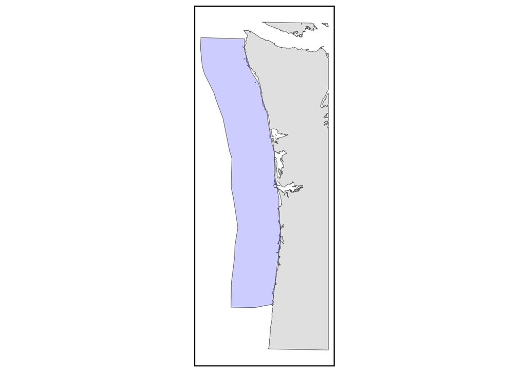

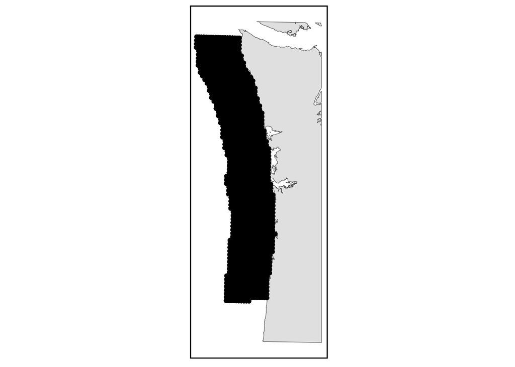

The trawl data for this taxon is visualized below:

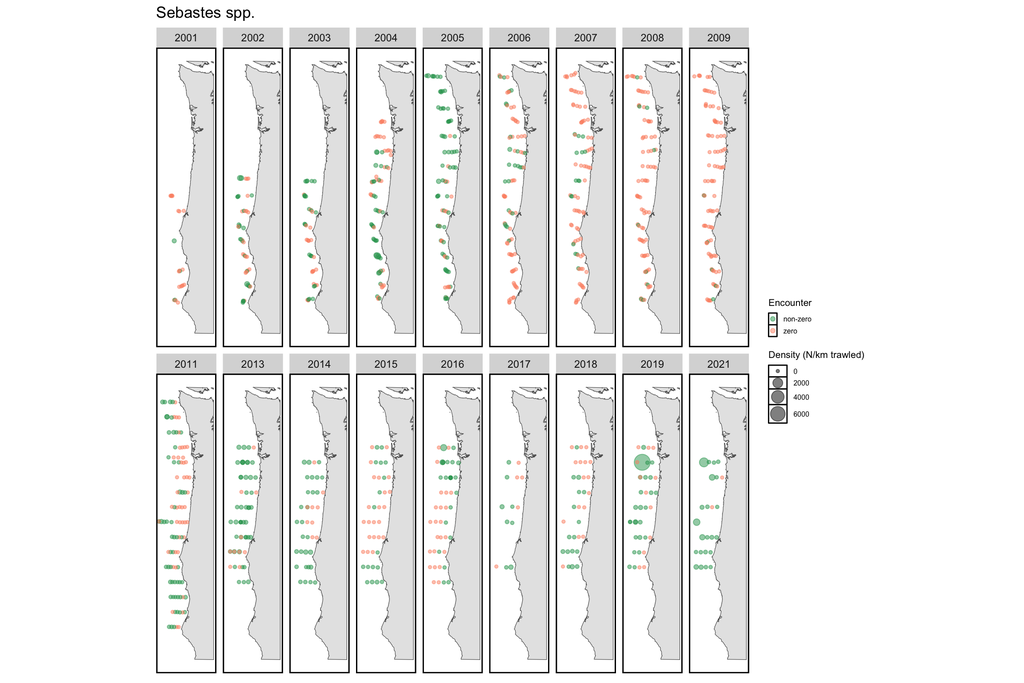

Density of rockfishes caught in the PRS/PWCC surveys

# Model selection process

## Step 1: Fit the base model with saturated fixed effects

We will first fit a model with all fixed effects included: temperature, distance from shore, and year.

- Year will be modeled as a factor
- Temperature and distance from shore will be modeled as linear predictors.

## Step 2: Tune the random effects, based on the model with saturated fixed effects

The primary random effects in this model are spatial and spatiotemporal random effects.

The options for the spatial random effects are as follows:

1. No spatial random fields
2. Spatial random fields (isotropic)
3. Spatial random fields (anisotropic)

The options for the spatiotemporal random effects are as follows:

1. No spatiotemporal random fields
2. Spatiotemporal random fields (isotropic, IID)
3. Spatiotemporal random fields (anisotropic, IID)
4. Spatiotemporal random fields (isotropic, AR1)
5. Spatiotemporal random fields (anisotropic, AR1)

However, it doesn’t make ecological sense for spatial fields to be anisotropic and spatiotemporal fields to be isotropic, or vice versa (spatial fields isotropic and spatiotemporal fields anisotropic). So, the result of crossing these options with this constraint are the following models:

- 1-1 No spatial random fields, no spatiotemporal random fields
- 1-2 No spatial random fields, spatiotemporal random fields (isotropic, IID)
- 1-3 No spatial random fields, spatiotemporal random fields (anisotropic, IID)
- 1-4 No spatial random fields, spatiotemporal random fields (isotropic, AR1)
- 1-5 No spatial random fields, spatiotemporal random fields (anisotropic, AR1)
- 2-1 Spatial random fields (isotropic), no spatiotemporal random fields
- 2-2 Spatial random fields (isotropic), spatiotemporal random fields (isotropic, IID)
- 2-4 Spatial random fields (isotropic), spatiotemporal random fields (isotropic, AR1)
- 3-1 Spatial random fields (anisotropic), no spatiotemporal random fields
- 3-3 Spatial random fields (anisotropic), spatiotemporal random fields (anisotropic, IID)
- 3-5 Spatial random fields (anisotropic), spatiotemporal random fields (anisotropic, AR1)

The first cross (Model 1-1, no spatial random fields and no spatiotemporal random fields) is the saturated fixed effects model. Therefore, we will proceed with the ten other candidate random effect structures.

### Fit candidate models

#### Model 1-2: No spatial random fields, spatiotemporal random fields (isotropic, IID)

#### Model 1-3: No spatial random fields, spatiotemporal random fields (anisotropic, IID)

#### Model 1-4: No spatial random fields, spatiotemporal random fields (isotropic, AR1)

#### Model 1-5: No spatial random fields, spatiotemporal random fields (anisotropic, AR1)

#### Model 2-1: Spatial random fields (isotropic), no spatiotemporal random fields

#### Model 2-2: Spatial random fields (isotropic), spatiotemporal random fields (isotropic, IID)

#### Model 2-4: Spatial random fields (isotropic), spatiotemporal random fields (isotropic, AR1)

#### Model 3-1: Spatial random fields (anisotropic), no spatiotemporal random fields

#### Model 3-3: Spatial random fields (anisotropic), spatiotemporal random fields (anisotropic, IID)

#### Model 3-5: Spatial random fields (anisotropic), spatiotemporal random fields (anisotropic, AR1)

### Compare candidate models

AIC and cAIC scores for the random effect structures.

| model | AIC | cAIC |
| --- | --- | --- |
| Spatial ON + Spatiotemporal IID (anisotropic) | 3851.12 | 3589.31 |
| Spatial OFF + Spatiotemporal AR1 (anisotropic) | 3853.30 | 3590.74 |
| Spatial ON + Spatiotemporal AR1 (anisotropic) | 3853.03 | 3590.96 |
| Spatial OFF + Spatiotemporal IID (anisotropic) | 3852.60 | 3591.36 |
| Spatial OFF + Spatiotemporal IID (isotropic) | 3865.49 | 3608.00 |
| Spatial OFF + Spatiotemporal AR1 (isotropic) | 3866.69 | 3608.09 |
| Spatial ON + Spatiotemporal OFF (isotropic) | 4212.67 | 4185.38 |
| Spatial ON + Spatiotemporal IID (isotropic) | 4214.67 | 4187.38 |
| Spatial ON + Spatiotemporal AR1 (isotropic) | 4214.67 | 4187.38 |
| Spatial ON + Spatiotemporal OFF (anisotropic) | 4217.57 | 4189.40 |
| Spatial OFF + Spatiotemporal OFF | 4299.54 | NA |

## Step 3: Tune fixed effects based on random effects selected in step 2

We have three covariates that we are exploring:

- Year
- Temperature
- Distance from shore

Year we will only model as a factor representing a year-wide intercept for the full survey region, without an autoregressive component. This is because we do not expect the abundance of salmon to be an autoregressive process (successive run years are not related in terms of abundance, given the salmon life history).

Temperature we can model as a linear fixed effect or a smooth spline (technically a random effect).

Distance from shore we can model as a linear fixed effect or a smooth spline (technically a random effect).

Therefore, our options for fixed effects are as follows:

- Year, as a factor (on/off)
- Temperature (off/linear/spline)
- Distance from shore (off/linear/spline)

Crossing these options (2 x 3 x 3) results in the following 18 candidate fixed effect structures:

1. Year (factor) + temperature (linear) + distance from shore (linear) - this is the base model that we used to test random effect structures.
2. Year (factor) + temperature (smooth spline) + distance from shore (smooth spline)
3. Year (factor) + temperature (linear) + distance from shore (smooth spline)
4. Year (factor) + temperature (smooth spline) + distance from shore (linear)
5. Year (factor) + temperature (linear)
6. Year (factor) + distance from shore (linear)
7. Year (factor) + temperature (smooth spline)
8. Year (factor) + distance from shore (smooth spline)
9. Year (factor)
10. Distance from shore (smooth spline) + temperature (smooth spline)
11. Distance from shore (smooth spline) + temperature (linear)
12. Distance from shore (linear) + temperature (smooth spline)
13. Distance from shore (linear) + temperature (linear)
14. Distance from shore (smooth spline)
15. Distance from shore (linear)
16. Temperature (smooth spline)
17. Temperature (linear)
18. No fixed effects

### Fit candidate models

#### Model 2: Year (factor) + temperature (smooth spline) + distance from shore (smooth spline)

#### Model 3: Year (factor) + temperature (linear)

#### Model 4: Year (factor) + distance from shore (linear)

#### Model 5: Year (factor) + temperature (smooth spline)

#### Model 6: Year (factor) + s(dist)

#### Model 7: Year (factor)

#### Model 8: No fixed effects

#### Model 9: temperature (smooth spline) + distance from shore (smooth spline)

#### Model 10: temperature (linear)

#### Model 11: distance from shore (linear)

#### Model 12: temperature (smooth spline)

#### Model 13: s(dist)

#### Model 14: temperature (linear) + distance from shore (linear)

#### Model 15: Year (factor) + temperature (smooth spline) + distance from shore (linear)

#### Model 16: Year (factor) + temperature (linear) + distance from shore (smooth spline)

#### Model 17: temperature (smooth spline) + distance from shore (linear)

#### Model 18: temperature (linear) + distance from shore (smooth spline)

### Compare candidate models

AIC and cAIC scores for the fixed effect structures.

| model | AIC | cAIC |
| --- | --- | --- |
| no fixed effects | 3898.45 | 3567.31 |
| temp | 3895.88 | 3569.67 |
| s(dist) | 3897.15 | 3569.79 |
| temp + s(dist) | 3897.68 | 3570.28 |
| s(temp) | 3897.88 | 3571.67 |
| s(temp) + s(dist) | 3899.68 | 3572.28 |
| temp + dist | 3896.37 | 3576.79 |
| dist | 3896.53 | 3578.02 |
| as.factor(year) | 3853.27 | 3578.19 |
| s(temp) + dist | 3898.37 | 3578.80 |
| as.factor(year) + temp | 3853.83 | 3580.60 |
| as.factor(year) + s(dist) | 3850.39 | 3582.17 |
| as.factor(year) + s(temp) | 3855.83 | 3582.61 |
| as.factor(year) + temp + s(dist) | 3852.11 | 3584.41 |
| as.factor(year) + s(temp) + s(dist) | 3854.11 | 3586.41 |
| as.factor(year) + dist | 3849.19 | 3586.90 |
| as.factor(year) + temp + dist | 3851.12 | 3589.31 |
| as.factor(year) + s(temp) + dist | 3853.12 | 3591.32 |

cAIC does not support the inclusion of any fixed effects.

Given that cAIC is the most appropriate model selection metric for our purposes, we will model the distribution of YOY rockfishes with the following model structure:

**density ~ spatial random fields (anisotropic) + spatiotemporal random fields (anisotropic, IID)**

#### Export the tables of AIC and cAIC for the supplemental results